# Differential treatment response of predicted endotypes of MEDIVIR

MTH (mth@nordicbio.com)

2024-10-30

# Introduction

Assess differential treatment response in predicted endotypes in MEDIVIR using the trained model from APPROACH.

```r
# Fetch predicted endotype labels
wkdir = "J:/16_GITHUB/MTH/IM_MTH_MEDIVIR/endotype_prediction/"
filename = "predicted.endotypes.baseline.tsv"
predicted.endotypes = read.table(file = paste0(wkdir, filename),
                                 header = TRUE)

# Get clinical information
wkdir = "R:/STATS/02 WP/WP001_RHEUMA/ST016_Medivir/data_gdpr/DATA_COLLECTED_2024/"
filename = "medivir_clinical_30OCT2024.tsv"
data.clinical = read.table(file = paste0(wkdir, filename),
                  header = TRUE,
                  sep = "\t") %>%
  rename(SUBJ_ID = SUBJECT) %>%
  mutate(VISIT = paste0("VISIT", VISIT)) %>%
  pivot_longer(cols = contains(c("WOMAC", "NRS")),
               names_to = "parameter") %>%
  pivot_wider(names_from = c("VISIT", "parameter"),
              values_from = value)

# Get sCXT-I and uCTX-II measurements (secondary outcome measures from study)
wkdir = "R:/STATS/02 WP/WP001_RHEUMA/ST016_Medivir/data_gdpr/DATA_COLLECTED_2024/"
filename = "medivir_biomarkers_RF_imputed_30OCT2024.tsv"
data.biomarkers = read.table(file = paste0(wkdir, filename),
                             header = TRUE) %>%
  rename(SUBJ_ID = SUBJECT) %>%
  select(SUBJ_ID, contains("CTX")) %>%
  # Back-transform measurements
  mutate(across(-SUBJ_ID, ~exp(.) - 1))

data = predicted.endotypes %>%
  left_join(data.clinical, by = "SUBJ_ID") %>%
  left_join(data.biomarkers, by = "SUBJ_ID") %>%
  # Calculate changes
  mutate(WOMACPAIN_CH = VISIT8_WOMAC_PAIN - VISIT2_WOMAC_PAIN,
         WOMACFUNC_CH = VISIT8_WOMAC_FUNC - VISIT2_WOMAC_FUNC,
         WOMACSTIFF_CH = VISIT8_WOMAC_STIFF - VISIT2_WOMAC_STIFF,
         NRSKNEEPAIN_CH = VISIT8_NRS_KNEE_PAIN - VISIT2_NRS_KNEE_PAIN,
         # Change biomarkers to percent change from baseline
         SCTX_CH = 100*(VISIT8_sCTX_I - VISIT2_sCTX_I)/VISIT2_sCTX_I,
         UCTXII_CH = 100*(VISIT8_uCTX_II_CREA - VISIT2_uCTX_II_CREA)/VISIT2_uCTX_II_CREA,
         # Add numerical differences in biomarkers as well
         SCTX_CH_NUM = VISIT8_sCTX_I - VISIT2_sCTX_I,
         UCTXII_CH_NUM = VISIT8_uCTX_II_CREA - VISIT2_uCTX_II_CREA) %>%
  mutate_at(vars(predicted_endotype, Sex), factor)

data$TREATMENT_SHORT = factor(data$TREATMENT_SHORT, levels = c("PLACEBO", "MIV-711"))
data$predicted_endotype = relevel(data$predicted_endotype, ref = "structural_damage")
```

# Treatment response - ANCOVA

## NRS Knee pain

Primary study outcome was change from visit 2 to 8 in NRS average target knee pain score.

```r
lm.fit = lm(NRSKNEEPAIN_CH ~ TREATMENT_SHORT + Age + Sex + BMI + TREATMENT_SHORT*predicted_endotype + VISIT2_NRS_KNEE_PAIN, data = data)
em = emmeans(lm.fit, ~TREATMENT_SHORT|predicted_endotype)
pairs(em, rev = TRUE) %>% rbind(adjust = "holm")
```

```
##  predicted_endotype contrast            estimate   SE  df t.ratio p.value
##  structural_damage  (MIV-711) - PLACEBO  -4.9196 4.87 205  -1.011  0.9398
##  inflammatory       (MIV-711) - PLACEBO  -0.0597 4.90 205  -0.012  0.9903
##  low_turnover       (MIV-711) - PLACEBO  -4.6222 5.83 205  -0.792  0.9398
##
## Results are averaged over some or all of the levels of: Sex
## P value adjustment: holm method for 3 tests
```

Get confidence intervals.

```r
res = summary(pairs(em, rev = TRUE) %>% rbind(adjust = "holm"))

# Structural damage
str.estimate.1 = res$estimate[1]
se = res$SE[1]
df = res$df[1]
str.lower.1 = str.estimate.1 - qt(p = 0.975, df = df)*se
str.upper.1 = str.estimate.1 + qt(p = 0.975, df = df)*se

# Inflammatory
infl.estimate.1 = res$estimate[2]
se = res$SE[2]
df = res$df[2]
infl.lower.1 = infl.estimate.1 - qt(p = 0.975, df = df)*se
infl.upper.1 = infl.estimate.1 + qt(p = 0.975, df = df)*se

# Low turnover
low.estimate.1 = res$estimate[3]
se = res$SE[3]
df = res$df[3]
low.lower.1 = low.estimate.1 - qt(p = 0.975, df = df)*se
low.upper.1 = low.estimate.1 + qt(p = 0.975, df = df)*se
```

Overall test if there is difference in effect (remove interaction term in simpler model).

```r
lm.fit2 = lm(NRSKNEEPAIN_CH ~ TREATMENT_SHORT + Age + Sex + BMI + VISIT2_NRS_KNEE_PAIN, data = data)
anova(lm.fit2, lm.fit)
```

```
## Analysis of Variance Table
##
## Model 1: NRSKNEEPAIN_CH ~ TREATMENT_SHORT + Age + Sex + BMI + VISIT2_NRS_KNEE_PAIN
## Model 2: NRSKNEEPAIN_CH ~ TREATMENT_SHORT + Age + Sex + BMI + TREATMENT_SHORT *
##     predicted_endotype + VISIT2_NRS_KNEE_PAIN
##   Res.Df   RSS Df Sum of Sq      F Pr(>F)
## 1    209 82694
## 2    205 81628  4    1066.6 0.6696 0.6137
```

Overall effect.

```r
em = emmeans(lm.fit2, ~TREATMENT_SHORT)
pairs(em, rev = TRUE) %>% rbind(adjust = "holm")
```

```
##  contrast            estimate   SE  df t.ratio p.value
##  (MIV-711) - PLACEBO    -3.27 2.92 209  -1.122  0.2631
##
## Results are averaged over some or all of the levels of: Sex
```

```r
res = summary(pairs(em, rev = TRUE) %>% rbind(adjust = "holm"))

# Overall effect
overall.estimate.1 = res$estimate
se = res$SE
df = res$df
overall.lower.1 = overall.estimate.1 - qt(p = 0.975, df = df)*se
overall.upper.1 = overall.estimate.1 + qt(p = 0.975, df = df)*se
```

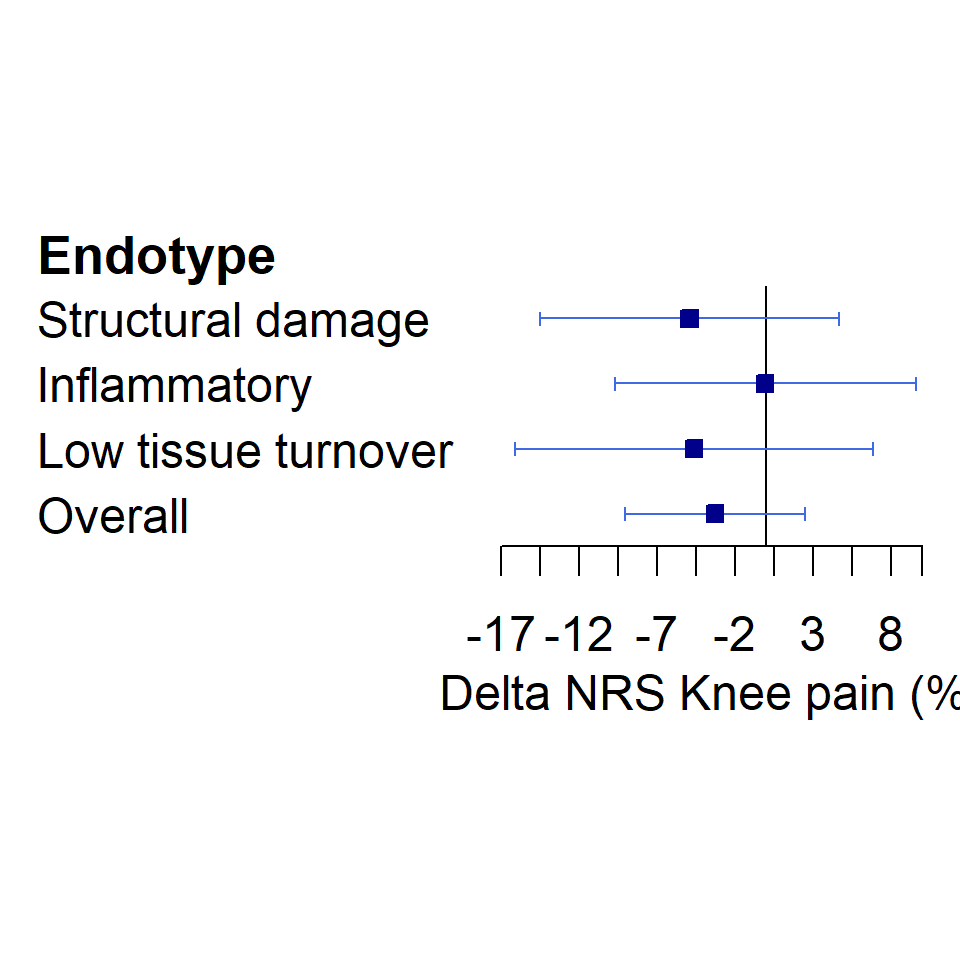

```r
dat.forest = tibble(mean = c(str.estimate.1, infl.estimate.1, low.estimate.1, overall.estimate.1),
       lower = c(str.lower.1, infl.lower.1, low.lower.1, overall.lower.1),
       upper = c(str.upper.1, infl.upper.1, low.upper.1, overall.upper.1),
       endotype = c("Structural damage", "Inflammatory", "Low tissue turnover", "Overall"))

dat.forest %>%
  forestplot(labeltext = endotype,
             xlab = "Delta NRS Knee pain (%)",
             ci.vertices = TRUE,
             lineheight =  unit(8.6,"mm"),
             boxsize = 0.25,
             col = fpColors(zero = "black")) |>
  fp_add_header(endotype = "Endotype") |>
  fp_set_style(box = "darkblue",
               line = "royalblue",
               txt_gp = fpTxtGp(xlab = gpar(cex = 1.5),
                                ticks = gpar(cex = 1.5),
                                cex = 1.5))
```

## WOMAC Pain

```r
lm.fit = lm(WOMACPAIN_CH ~ TREATMENT_SHORT + Age + Sex + BMI + TREATMENT_SHORT*predicted_endotype + VISIT2_WOMAC_PAIN, data = data)
em = emmeans(lm.fit, ~TREATMENT_SHORT|predicted_endotype)
pairs(em, rev = TRUE) %>% rbind(adjust = "holm")
```

```
##  predicted_endotype contrast            estimate   SE  df t.ratio p.value
##  structural_damage  (MIV-711) - PLACEBO    -4.43 4.70 205  -0.941  0.6960
##  inflammatory       (MIV-711) - PLACEBO    -1.86 4.75 205  -0.392  0.6960
##  low_turnover       (MIV-711) - PLACEBO    -8.75 5.58 205  -1.568  0.3553
##
## Results are averaged over some or all of the levels of: Sex
## P value adjustment: holm method for 3 tests
```

Get confidence intervals.

```r
res = summary(pairs(em, rev = TRUE) %>% rbind(adjust = "holm"))

# Structural damage
str.estimate.2 = res$estimate[1]
se = res$SE[1]
df = res$df[1]
str.lower.2 = str.estimate.2 - qt(p = 0.975, df = df)*se
str.upper.2 = str.estimate.2 + qt(p = 0.975, df = df)*se

# Inflammatory
infl.estimate.2 = res$estimate[2]
se = res$SE[2]
df = res$df[2]
infl.lower.2 = infl.estimate.2 - qt(p = 0.975, df = df)*se
infl.upper.2 = infl.estimate.2 + qt(p = 0.975, df = df)*se

# Low turnover
low.estimate.2 = res$estimate[3]
se = res$SE[3]
df = res$df[3]
low.lower.2 = low.estimate.2 - qt(p = 0.975, df = df)*se
low.upper.2 = low.estimate.2 + qt(p = 0.975, df = df)*se
```

Overall test if there is difference in effect (remove interaction term in simpler model).

```r
lm.fit2 = lm(WOMACPAIN_CH ~ TREATMENT_SHORT + Age + Sex + BMI + VISIT2_WOMAC_PAIN, data = data)
anova(lm.fit2, lm.fit)
```

```
## Analysis of Variance Table
##
## Model 1: WOMACPAIN_CH ~ TREATMENT_SHORT + Age + Sex + BMI + VISIT2_WOMAC_PAIN
## Model 2: WOMACPAIN_CH ~ TREATMENT_SHORT + Age + Sex + BMI + TREATMENT_SHORT *
##     predicted_endotype + VISIT2_WOMAC_PAIN
##   Res.Df   RSS Df Sum of Sq      F Pr(>F)
## 1    209 77790
## 2    205 76392  4      1398 0.9379 0.4429
```

Overall effect.

```r
em = emmeans(lm.fit2, ~TREATMENT_SHORT)
pairs(em, rev = TRUE) %>% rbind(adjust = "holm")
```

```
##  contrast            estimate   SE  df t.ratio p.value
##  (MIV-711) - PLACEBO    -4.38 2.83 209  -1.546  0.1237
##
## Results are averaged over some or all of the levels of: Sex
```

```r
res = summary(pairs(em, rev = TRUE) %>% rbind(adjust = "holm"))

# Overall effect
overall.estimate.2 = res$estimate
se = res$SE
df = res$df
overall.lower.2 = overall.estimate.2 - qt(p = 0.975, df = df)*se
overall.upper.2 = overall.estimate.2 + qt(p = 0.975, df = df)*se
```

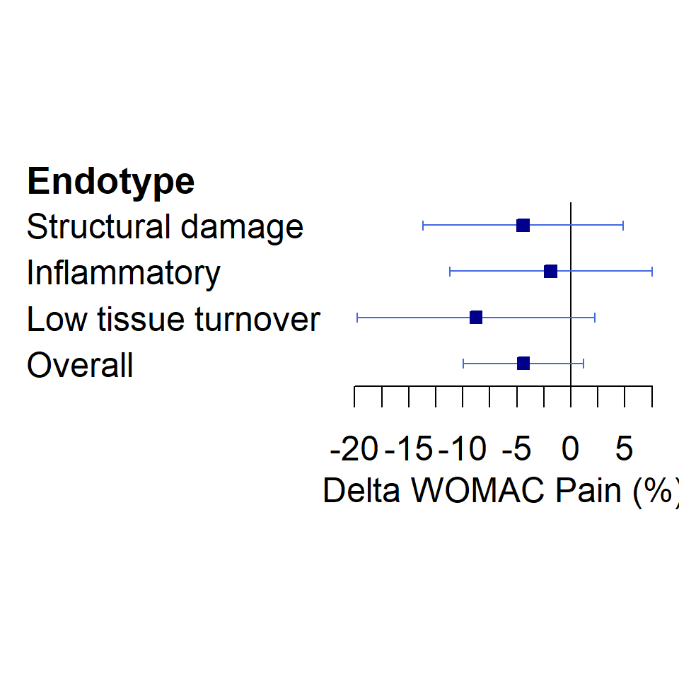

```r
dat.forest = tibble(mean = c(str.estimate.2, infl.estimate.2, low.estimate.2, overall.estimate.2),
       lower = c(str.lower.2, infl.lower.2, low.lower.2, overall.lower.2),
       upper = c(str.upper.2, infl.upper.2, low.upper.2, overall.upper.2),
       endotype = c("Structural damage", "Inflammatory", "Low tissue turnover", "Overall"))

dat.forest %>%
  forestplot(labeltext = endotype,
             xlab = "Delta WOMAC Pain (%)",
             ci.vertices = TRUE,
             boxsize = 0.25,
             lineheight =  unit(8.6,"mm"),
             col = fpColors(zero = "black")) |>
  fp_add_header(endotype = "Endotype") |>
  fp_set_style(box = "darkblue",
               line = "royalblue",
               txt_gp = fpTxtGp(xlab = gpar(cex = 1.5),
                                ticks = gpar(cex = 1.5),
                                cex = 1.5))
```

## WOMAC Function

```r
lm.fit = lm(WOMACFUNC_CH ~ TREATMENT_SHORT + Age + Sex + BMI + TREATMENT_SHORT*predicted_endotype + VISIT2_WOMAC_FUNC, data = data)
em = emmeans(lm.fit, ~TREATMENT_SHORT|predicted_endotype)
pairs(em, rev = TRUE) %>% rbind(adjust = "holm")
```

```
##  predicted_endotype contrast            estimate   SE  df t.ratio p.value
##  structural_damage  (MIV-711) - PLACEBO    -3.51 4.90 205  -0.717  0.9487
##  inflammatory       (MIV-711) - PLACEBO    -2.34 4.95 205  -0.472  0.9487
##  low_turnover       (MIV-711) - PLACEBO    -8.65 5.81 205  -1.490  0.4136
##
## Results are averaged over some or all of the levels of: Sex
## P value adjustment: holm method for 3 tests
```

Get confidence intervals.

```r
res = summary(pairs(em, rev = TRUE) %>% rbind(adjust = "holm"))

# Structural damage
str.estimate.3 = res$estimate[1]
se = res$SE[1]
df = res$df[1]
str.lower.3 = str.estimate.3 - qt(p = 0.975, df = df)*se
str.upper.3 = str.estimate.3 + qt(p = 0.975, df = df)*se

# Inflammatory
infl.estimate.3 = res$estimate[2]
se = res$SE[2]
df = res$df[2]
infl.lower.3 = infl.estimate.3 - qt(p = 0.975, df = df)*se
infl.upper.3 = infl.estimate.3 + qt(p = 0.975, df = df)*se

# Low turnover
low.estimate.3 = res$estimate[3]
se = res$SE[3]
df = res$df[3]
low.lower.3 = low.estimate.3 - qt(p = 0.975, df = df)*se
low.upper.3 = low.estimate.3 + qt(p = 0.975, df = df)*se
```

Overall test if there is difference in effect (remove interaction term in simpler model).

```r
lm.fit2 = lm(WOMACFUNC_CH ~ TREATMENT_SHORT + Age + Sex + BMI + VISIT2_WOMAC_FUNC, data = data)
anova(lm.fit2, lm.fit)
```

```
## Analysis of Variance Table
##
## Model 1: WOMACFUNC_CH ~ TREATMENT_SHORT + Age + Sex + BMI + VISIT2_WOMAC_FUNC
## Model 2: WOMACFUNC_CH ~ TREATMENT_SHORT + Age + Sex + BMI + TREATMENT_SHORT *
##     predicted_endotype + VISIT2_WOMAC_FUNC
##   Res.Df   RSS Df Sum of Sq      F Pr(>F)
## 1    209 84785
## 2    205 82803  4    1982.1 1.2268 0.3006
```

Overall effect.

```r
em = emmeans(lm.fit2, ~TREATMENT_SHORT)
pairs(em, rev = TRUE) %>% rbind(adjust = "holm")
```

```
##  contrast            estimate   SE  df t.ratio p.value
##  (MIV-711) - PLACEBO    -4.15 2.96 209  -1.402  0.1624
##
## Results are averaged over some or all of the levels of: Sex
```

```r
res = summary(pairs(em, rev = TRUE) %>% rbind(adjust = "holm"))

# Overall effect
overall.estimate.3 = res$estimate
se = res$SE
df = res$df
overall.lower.3 = overall.estimate.3 - qt(p = 0.975, df = df)*se
overall.upper.3 = overall.estimate.3 + qt(p = 0.975, df = df)*se
```

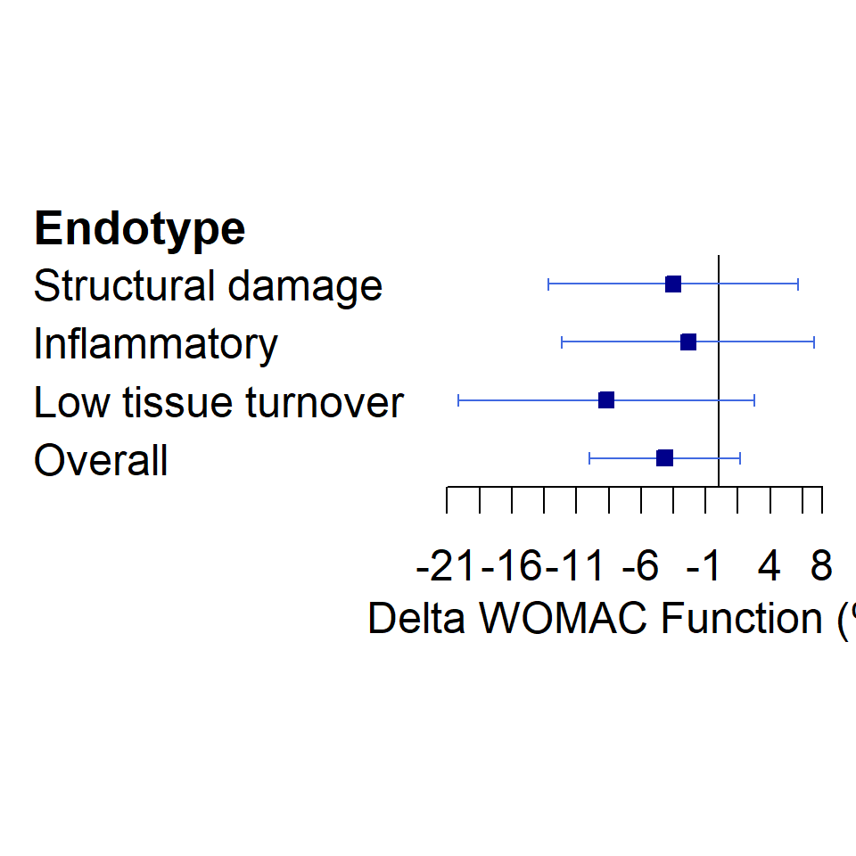

```r
dat.forest = tibble(mean = c(str.estimate.3, infl.estimate.3, low.estimate.3, overall.estimate.3),
       lower = c(str.lower.3, infl.lower.3, low.lower.3, overall.lower.3),
       upper = c(str.upper.3, infl.upper.3, low.upper.3, overall.upper.3),
       endotype = c("Structural damage", "Inflammatory", "Low tissue turnover", "Overall"))

dat.forest %>%
  forestplot(labeltext = endotype,
             xlab = "Delta WOMAC Function (%)",
             ci.vertices = TRUE,
             boxsize = 0.25,
             lineheight =  unit(8.6,"mm"),
             col = fpColors(zero = "black")) |>
  fp_add_header(endotype = "Endotype") |>
  fp_set_style(box = "darkblue",
               line = "royalblue",
               txt_gp = fpTxtGp(xlab = gpar(cex = 1.5),
                                ticks = gpar(cex = 1.5),
                                cex = 1.5))
```

## WOMAC Stiffness

```r
lm.fit = lm(WOMACSTIFF_CH ~ TREATMENT_SHORT + Age + Sex + BMI + TREATMENT_SHORT*predicted_endotype + VISIT2_WOMAC_STIFF, data = data)
em = emmeans(lm.fit, ~TREATMENT_SHORT|predicted_endotype)
pairs(em, rev = TRUE) %>% rbind(adjust = "holm")
```

```
##  predicted_endotype contrast            estimate   SE  df t.ratio p.value
##  structural_damage  (MIV-711) - PLACEBO    -3.51 5.30 205  -0.661  0.9301
##  inflammatory       (MIV-711) - PLACEBO    -3.92 5.35 205  -0.732  0.9301
##  low_turnover       (MIV-711) - PLACEBO   -10.73 6.29 205  -1.706  0.2684
##
## Results are averaged over some or all of the levels of: Sex
## P value adjustment: holm method for 3 tests
```

Get confidence intervals.

```r
res = summary(pairs(em, rev = TRUE) %>% rbind(adjust = "holm"))

# Structural damage
str.estimate.4 = res$estimate[1]
se = res$SE[1]
df = res$df[1]
str.lower.4 = str.estimate.4 - qt(p = 0.975, df = df)*se
str.upper.4 = str.estimate.4 + qt(p = 0.975, df = df)*se

# Inflammatory
infl.estimate.4 = res$estimate[2]
se = res$SE[2]
df = res$df[2]
infl.lower.4 = infl.estimate.4 - qt(p = 0.975, df = df)*se
infl.upper.4 = infl.estimate.4 + qt(p = 0.975, df = df)*se

# Low turnover
low.estimate.4 = res$estimate[3]
se = res$SE[3]
df = res$df[3]
low.lower.4 = low.estimate.4 - qt(p = 0.975, df = df)*se
low.upper.4 = low.estimate.4 + qt(p = 0.975, df = df)*se
```

Overall test if there is difference in effect (remove interaction term in simpler model).

```r
lm.fit2 = lm(WOMACSTIFF_CH ~ TREATMENT_SHORT + Age + Sex + BMI + VISIT2_WOMAC_STIFF, data = data)
anova(lm.fit2, lm.fit)
```

```
## Analysis of Variance Table
##
## Model 1: WOMACSTIFF_CH ~ TREATMENT_SHORT + Age + Sex + BMI + VISIT2_WOMAC_STIFF
## Model 2: WOMACSTIFF_CH ~ TREATMENT_SHORT + Age + Sex + BMI + TREATMENT_SHORT *
##     predicted_endotype + VISIT2_WOMAC_STIFF
##   Res.Df    RSS Df Sum of Sq      F Pr(>F)
## 1    209 100254
## 2    205  97166  4    3088.1 1.6288 0.1683
```

Overall effect.

```r
em = emmeans(lm.fit2, ~TREATMENT_SHORT)
pairs(em, rev = TRUE) %>% rbind(adjust = "holm")
```

```
##  contrast            estimate   SE  df t.ratio p.value
##  (MIV-711) - PLACEBO    -5.13 3.21 209  -1.596  0.1120
##
## Results are averaged over some or all of the levels of: Sex
```

```r
res = summary(pairs(em, rev = TRUE) %>% rbind(adjust = "holm"))

# Overall effect
overall.estimate.4 = res$estimate
se = res$SE
df = res$df
overall.lower.4 = overall.estimate.4 - qt(p = 0.975, df = df)*se
overall.upper.4 = overall.estimate.4 + qt(p = 0.975, df = df)*se
```

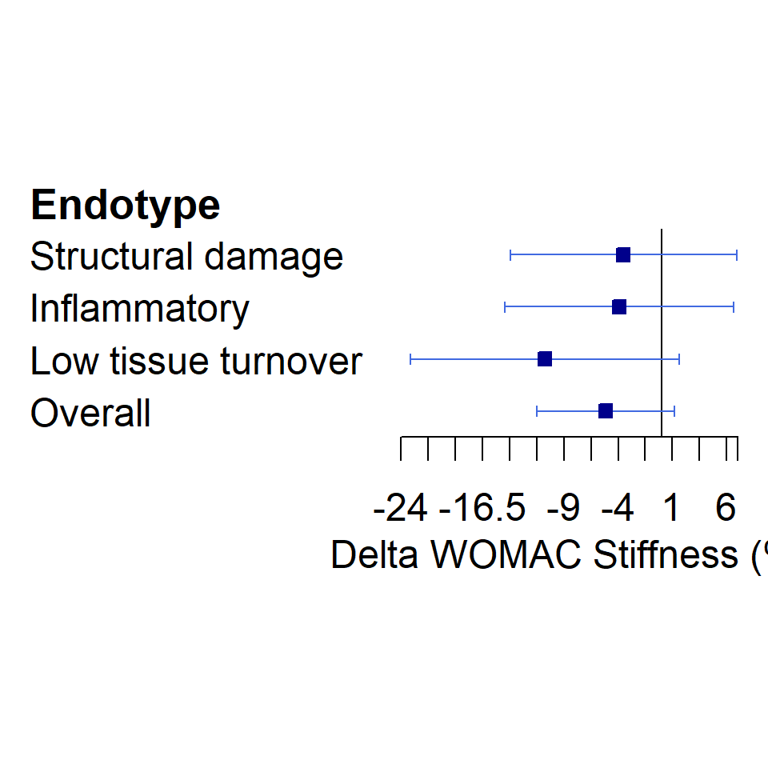

```r
dat.forest = tibble(mean = c(str.estimate.4, infl.estimate.4, low.estimate.4, overall.estimate.4),
       lower = c(str.lower.4, infl.lower.4, low.lower.4, overall.lower.4),
       upper = c(str.upper.4, infl.upper.4, low.upper.4, overall.upper.4),
       endotype = c("Structural damage", "Inflammatory", "Low tissue turnover", "Overall"))

dat.forest %>%
  forestplot(labeltext = endotype,
             xlab = "Delta WOMAC Stiffness (%)",
             ci.vertices = TRUE,
             boxsize = 0.25,
             lineheight =  unit(8.6,"mm"),
             col = fpColors(zero = "black")) |>
  fp_add_header(endotype = "Endotype") |>
  fp_set_style(box = "darkblue",
               line = "royalblue",
               txt_gp = fpTxtGp(xlab = gpar(cex = 1.5),
                                ticks = gpar(cex = 1.5),
                                cex = 1.5))
```

## sCTX-I

```r
lm.fit = lm(SCTX_CH ~ TREATMENT_SHORT + Age + Sex + BMI + TREATMENT_SHORT*predicted_endotype + VISIT2_sCTX_I, data = data)
em = emmeans(lm.fit, ~TREATMENT_SHORT|predicted_endotype)
pairs(em, rev = TRUE) %>% rbind(adjust = "holm")
```

```
##  predicted_endotype contrast            estimate   SE  df t.ratio p.value
##  structural_damage  (MIV-711) - PLACEBO    -33.3 7.70 205  -4.327  <.0001
##  inflammatory       (MIV-711) - PLACEBO    -56.6 7.76 205  -7.296  <.0001
##  low_turnover       (MIV-711) - PLACEBO    -40.9 9.13 205  -4.478  <.0001
##
## Results are averaged over some or all of the levels of: Sex
## P value adjustment: holm method for 3 tests
```

Get confidence intervals.

```r
res = summary(pairs(em, rev = TRUE) %>% rbind(adjust = "holm"))

# Structural damage
str.estimate.5 = res$estimate[1]
se = res$SE[1]
df = res$df[1]
str.lower.5 = str.estimate.5 - qt(p = 0.975, df = df)*se
str.upper.5 = str.estimate.5 + qt(p = 0.975, df = df)*se

# Inflammatory
infl.estimate.5 = res$estimate[2]
se = res$SE[2]
df = res$df[2]
infl.lower.5 = infl.estimate.5 - qt(p = 0.975, df = df)*se
infl.upper.5 = infl.estimate.5 + qt(p = 0.975, df = df)*se

# Low turnover
low.estimate.5 = res$estimate[3]
se = res$SE[3]
df = res$df[3]
low.lower.5 = low.estimate.5 - qt(p = 0.975, df = df)*se
low.upper.5 = low.estimate.5 + qt(p = 0.975, df = df)*se
```

Overall test if there is difference in effect (remove interaction term in simpler model).

```r
lm.fit2 = lm(SCTX_CH ~ TREATMENT_SHORT + Age + Sex + BMI + VISIT2_sCTX_I, data = data)
anova(lm.fit2, lm.fit)
```

```
## Analysis of Variance Table
##
## Model 1: SCTX_CH ~ TREATMENT_SHORT + Age + Sex + BMI + VISIT2_sCTX_I
## Model 2: SCTX_CH ~ TREATMENT_SHORT + Age + Sex + BMI + TREATMENT_SHORT *
##     predicted_endotype + VISIT2_sCTX_I
##   Res.Df    RSS Df Sum of Sq      F Pr(>F)
## 1    209 210250
## 2    205 204452  4    5797.8 1.4533 0.2178
```

Overall effect.

```r
em = emmeans(lm.fit2, ~TREATMENT_SHORT)
pairs(em, rev = TRUE) %>% rbind(adjust = "holm")
```

```
##  contrast            estimate   SE  df t.ratio p.value
##  (MIV-711) - PLACEBO    -43.2 4.65 209  -9.293  <.0001
##
## Results are averaged over some or all of the levels of: Sex
```

```r
res = summary(pairs(em, rev = TRUE) %>% rbind(adjust = "holm"))

# Overall effect
overall.estimate.5 = res$estimate
se = res$SE
df = res$df
overall.lower.5 = overall.estimate.5 - qt(p = 0.975, df = df)*se
overall.upper.5 = overall.estimate.5 + qt(p = 0.975, df = df)*se
```

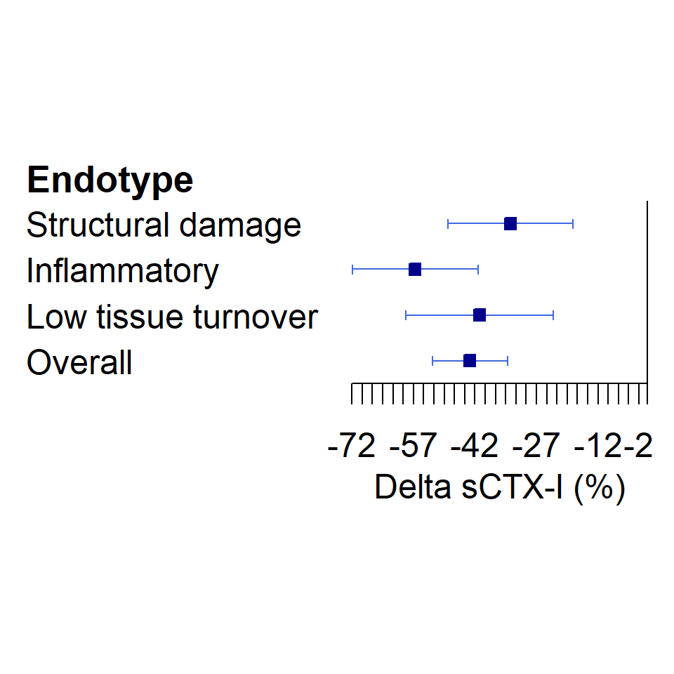

```r
dat.forest = tibble(mean = c(str.estimate.5, infl.estimate.5, low.estimate.5, overall.estimate.5),
       lower = c(str.lower.5, infl.lower.5, low.lower.5, overall.lower.5),
       upper = c(str.upper.5, infl.upper.5, low.upper.5, overall.upper.5),
       endotype = c("Structural damage", "Inflammatory", "Low tissue turnover", "Overall"))

dat.forest %>%
  forestplot(labeltext = endotype,
             xlab = "Delta sCTX-I (%)",
             ci.vertices = TRUE,
             boxsize = 0.25,
             lineheight =  unit(8.6,"mm"),
             col = fpColors(zero = "black")) |>
  fp_add_header(endotype = "Endotype") |>
  fp_set_style(box = "darkblue",
               line = "royalblue",
               txt_gp = fpTxtGp(xlab = gpar(cex = 1.5),
                                ticks = gpar(cex = 1.5),
                                cex = 1.5))
```

## uCTX-II

```r
lm.fit = lm(UCTXII_CH ~ TREATMENT_SHORT + Age + Sex + BMI + TREATMENT_SHORT*predicted_endotype + VISIT2_uCTX_II_CREA, data = data)
em = emmeans(lm.fit, ~TREATMENT_SHORT|predicted_endotype)
pairs(em, rev = TRUE) %>% rbind(adjust = "holm")
```

```
##  predicted_endotype contrast            estimate   SE  df t.ratio p.value
##  structural_damage  (MIV-711) - PLACEBO    -55.8 10.6 205  -5.260  <.0001
##  inflammatory       (MIV-711) - PLACEBO    -68.9 10.7 205  -6.453  <.0001
##  low_turnover       (MIV-711) - PLACEBO    -19.2 12.6 205  -1.531  0.1273
##
## Results are averaged over some or all of the levels of: Sex
## P value adjustment: holm method for 3 tests
```

Get confidence intervals.

```r
res = summary(pairs(em, rev = TRUE) %>% rbind(adjust = "holm"))

# Structural damage
str.estimate.6 = res$estimate[1]
se = res$SE[1]
df = res$df[1]
str.lower.6 = str.estimate.6 - qt(p = 0.975, df = df)*se
str.upper.6 = str.estimate.6 + qt(p = 0.975, df = df)*se

# Inflammatory
infl.estimate.6 = res$estimate[2]
se = res$SE[2]
df = res$df[2]
infl.lower.6 = infl.estimate.6 - qt(p = 0.975, df = df)*se
infl.upper.6 = infl.estimate.6 + qt(p = 0.975, df = df)*se

# Low turnover
low.estimate.6 = res$estimate[3]
se = res$SE[3]
df = res$df[3]
low.lower.6 = low.estimate.6 - qt(p = 0.975, df = df)*se
low.upper.6 = low.estimate.6 + qt(p = 0.975, df = df)*se
```

Overall test if there is difference in effect (remove interaction term in simpler model).

```r
lm.fit2 = lm(UCTXII_CH ~ TREATMENT_SHORT + Age + Sex + BMI + VISIT2_uCTX_II_CREA, data = data)
anova(lm.fit2, lm.fit)
```

```
## Analysis of Variance Table
##
## Model 1: UCTXII_CH ~ TREATMENT_SHORT + Age + Sex + BMI + VISIT2_uCTX_II_CREA
## Model 2: UCTXII_CH ~ TREATMENT_SHORT + Age + Sex + BMI + TREATMENT_SHORT *
##     predicted_endotype + VISIT2_uCTX_II_CREA
##   Res.Df    RSS Df Sum of Sq      F Pr(>F)
## 1    209 407239
## 2    205 387279  4     19959 2.6413 0.0349 *
## ---
## Signif. codes:  0 '***' 0.001 '**' 0.01 '*' 0.05 '.' 0.1 ' ' 1
```

Overall effect.

```r
em = emmeans(lm.fit2, ~TREATMENT_SHORT)
pairs(em, rev = TRUE) %>% rbind(adjust = "holm")
```

```
##  contrast            estimate   SE  df t.ratio p.value
##  (MIV-711) - PLACEBO    -51.3 6.48 209  -7.910  <.0001
##
## Results are averaged over some or all of the levels of: Sex
```

```r
res = summary(pairs(em, rev = TRUE) %>% rbind(adjust = "holm"))

# Overall effect
overall.estimate.6 = res$estimate
se = res$SE
df = res$df
overall.lower.6 = overall.estimate.6 - qt(p = 0.975, df = df)*se
overall.upper.6 = overall.estimate.6 + qt(p = 0.975, df = df)*se
```

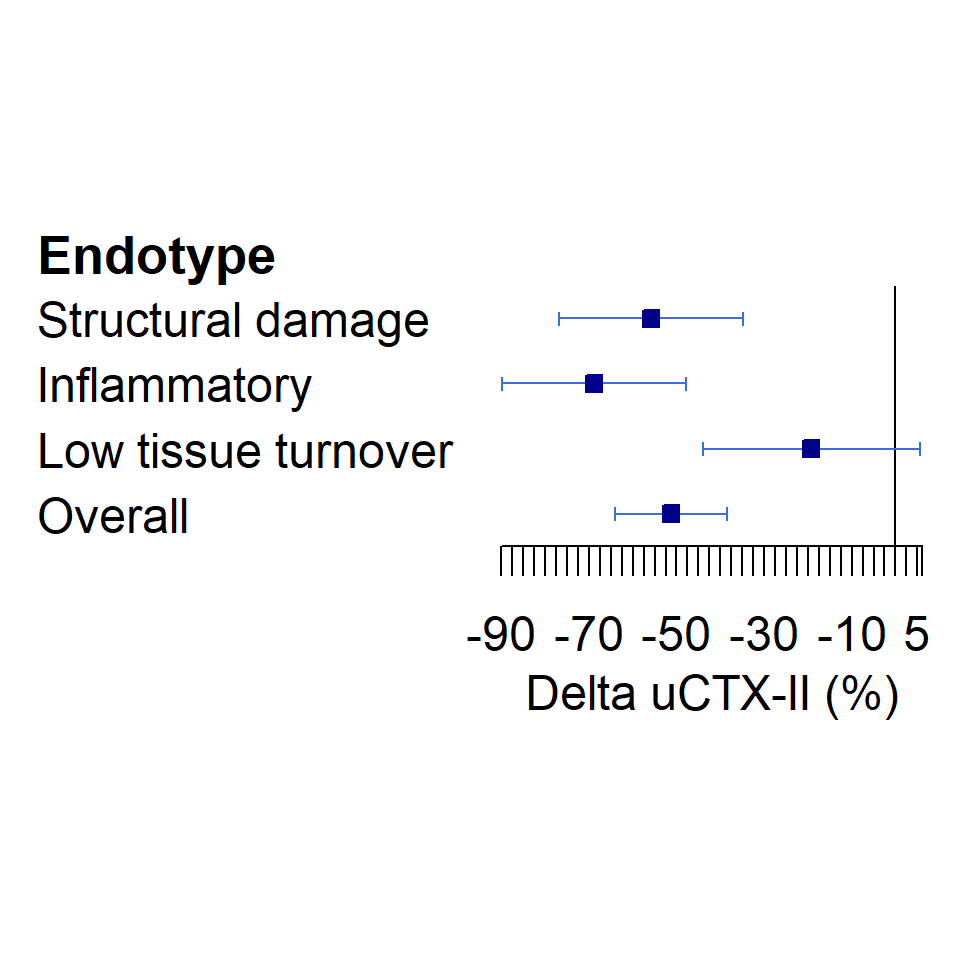

```r
dat.forest = tibble(mean = c(str.estimate.6, infl.estimate.6, low.estimate.6, overall.estimate.6),
       lower = c(str.lower.6, infl.lower.6, low.lower.6, overall.lower.6),
       upper = c(str.upper.6, infl.upper.6, low.upper.6, overall.upper.6),
       endotype = c("Structural damage", "Inflammatory", "Low tissue turnover", "Overall"))

dat.forest %>%
  forestplot(labeltext = endotype,
             xlab = "Delta uCTX-II (%)",
             ci.vertices = TRUE,
             boxsize = 0.25,
             lineheight =  unit(8.6,"mm"),
             col = fpColors(zero = "black")) |>
  fp_add_header(endotype = "Endotype") |>
  fp_set_style(box = "darkblue",
               line = "royalblue",
               txt_gp = fpTxtGp(xlab = gpar(cex = 1.5),
                                ticks = gpar(cex = 1.5),
                                cex = 1.5))
```

## sCTX-I - numerical difference

```r
lm.fit = lm(SCTX_CH_NUM ~ TREATMENT_SHORT + Age + Sex + BMI + TREATMENT_SHORT*predicted_endotype + VISIT2_sCTX_I, data = data)
em = emmeans(lm.fit, ~TREATMENT_SHORT|predicted_endotype)
pairs(em, rev = TRUE) %>% rbind(adjust = "holm")
```

```
##  predicted_endotype contrast            estimate     SE  df t.ratio p.value
##  structural_damage  (MIV-711) - PLACEBO   -0.204 0.0354 205  -5.769  <.0001
##  inflammatory       (MIV-711) - PLACEBO   -0.205 0.0356 205  -5.751  <.0001
##  low_turnover       (MIV-711) - PLACEBO   -0.161 0.0420 205  -3.832  0.0002
##
## Results are averaged over some or all of the levels of: Sex
## P value adjustment: holm method for 3 tests
```

Get confidence intervals.

```r
res = summary(pairs(em, rev = TRUE) %>% rbind(adjust = "holm"))

# Structural damage
str.estimate.7 = res$estimate[1]
se = res$SE[1]
df = res$df[1]
str.lower.7 = str.estimate.7 - qt(p = 0.975, df = df)*se
str.upper.7 = str.estimate.7 + qt(p = 0.975, df = df)*se

# Inflammatory
infl.estimate.7 = res$estimate[2]
se = res$SE[2]
df = res$df[2]
infl.lower.7 = infl.estimate.7 - qt(p = 0.975, df = df)*se
infl.upper.7 = infl.estimate.7 + qt(p = 0.975, df = df)*se

# Low turnover
low.estimate.7 = res$estimate[3]
se = res$SE[3]
df = res$df[3]
low.lower.7 = low.estimate.7 - qt(p = 0.975, df = df)*se
low.upper.7 = low.estimate.7 + qt(p = 0.975, df = df)*se
```

Overall test if there is difference in effect (remove interaction term in simpler model).

```r
lm.fit2 = lm(SCTX_CH_NUM ~ TREATMENT_SHORT + Age + Sex + BMI + VISIT2_sCTX_I, data = data)
anova(lm.fit2, lm.fit)
```

```
## Analysis of Variance Table
##
## Model 1: SCTX_CH_NUM ~ TREATMENT_SHORT + Age + Sex + BMI + VISIT2_sCTX_I
## Model 2: SCTX_CH_NUM ~ TREATMENT_SHORT + Age + Sex + BMI + TREATMENT_SHORT *
##     predicted_endotype + VISIT2_sCTX_I
##   Res.Df    RSS Df Sum of Sq      F Pr(>F)
## 1    209 4.3633
## 2    205 4.3180  4  0.045375 0.5386 0.7076
```

Overall effect.

```r
em = emmeans(lm.fit2, ~TREATMENT_SHORT)
pairs(em, rev = TRUE) %>% rbind(adjust = "holm")
```

```
##  contrast            estimate     SE  df t.ratio p.value
##  (MIV-711) - PLACEBO   -0.191 0.0212 209  -9.016  <.0001
##
## Results are averaged over some or all of the levels of: Sex
```

```r
res = summary(pairs(em, rev = TRUE) %>% rbind(adjust = "holm"))

# Overall effect
overall.estimate.7 = res$estimate
se = res$SE
df = res$df
overall.lower.7 = overall.estimate.7 - qt(p = 0.975, df = df)*se
overall.upper.7 = overall.estimate.7 + qt(p = 0.975, df = df)*se
```

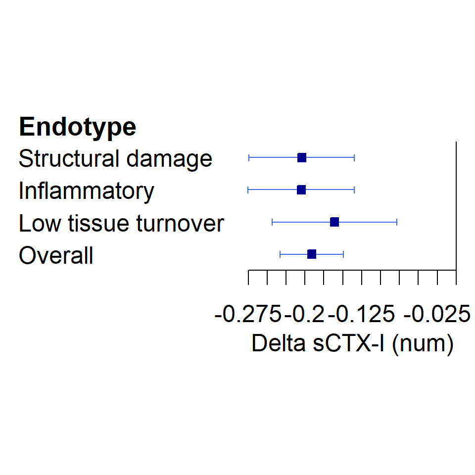

```r
dat.forest = tibble(mean = c(str.estimate.7, infl.estimate.7, low.estimate.7, overall.estimate.7),
       lower = c(str.lower.7, infl.lower.7, low.lower.7, overall.lower.7),
       upper = c(str.upper.7, infl.upper.7, low.upper.7, overall.upper.7),
       endotype = c("Structural damage", "Inflammatory", "Low tissue turnover", "Overall"))

dat.forest %>%
  forestplot(labeltext = endotype,
             xlab = "Delta sCTX-I (num)",
             ci.vertices = TRUE,
             boxsize = 0.25,
             lineheight =  unit(8.6,"mm"),
             col = fpColors(zero = "black")) |>
  fp_add_header(endotype = "Endotype") |>
  fp_set_style(box = "darkblue",
               line = "royalblue",
               txt_gp = fpTxtGp(xlab = gpar(cex = 1.5),
                                ticks = gpar(cex = 1.5),
                                cex = 1.5))
```

## uCTX-II - numerical difference

```r
lm.fit = lm(UCTXII_CH_NUM ~ TREATMENT_SHORT + Age + Sex + BMI + TREATMENT_SHORT*predicted_endotype + VISIT2_uCTX_II_CREA, data = data)
em = emmeans(lm.fit, ~TREATMENT_SHORT|predicted_endotype)
pairs(em, rev = TRUE) %>% rbind(adjust = "holm")
```

```
##  predicted_endotype contrast            estimate   SE  df t.ratio p.value
##  structural_damage  (MIV-711) - PLACEBO   -266.2 44.0 205  -6.055  <.0001
##  inflammatory       (MIV-711) - PLACEBO   -277.4 44.2 205  -6.269  <.0001
##  low_turnover       (MIV-711) - PLACEBO    -94.6 52.0 205  -1.819  0.0704
##
## Results are averaged over some or all of the levels of: Sex
## P value adjustment: holm method for 3 tests
```

Get confidence intervals.

```r
res = summary(pairs(em, rev = TRUE) %>% rbind(adjust = "holm"))

# Structural damage
str.estimate.8 = res$estimate[1]
se = res$SE[1]
df = res$df[1]
str.lower.8 = str.estimate.8 - qt(p = 0.975, df = df)*se
str.upper.8 = str.estimate.8 + qt(p = 0.975, df = df)*se

# Inflammatory
infl.estimate.8 = res$estimate[2]
se = res$SE[2]
df = res$df[2]
infl.lower.8 = infl.estimate.8 - qt(p = 0.975, df = df)*se
infl.upper.8 = infl.estimate.8 + qt(p = 0.975, df = df)*se

# Low turnover
low.estimate.8 = res$estimate[3]
se = res$SE[3]
df = res$df[3]
low.lower.8 = low.estimate.8 - qt(p = 0.975, df = df)*se
low.upper.8 = low.estimate.8 + qt(p = 0.975, df = df)*se
```

Overall test if there is difference in effect (remove interaction term in simpler model).

```r
lm.fit2 = lm(UCTXII_CH_NUM ~ TREATMENT_SHORT + Age + Sex + BMI + VISIT2_uCTX_II_CREA, data = data)
anova(lm.fit2, lm.fit)
```

```
## Analysis of Variance Table
##
## Model 1: UCTXII_CH_NUM ~ TREATMENT_SHORT + Age + Sex + BMI + VISIT2_uCTX_II_CREA
## Model 2: UCTXII_CH_NUM ~ TREATMENT_SHORT + Age + Sex + BMI + TREATMENT_SHORT *
##     predicted_endotype + VISIT2_uCTX_II_CREA
##   Res.Df     RSS Df Sum of Sq      F  Pr(>F)
## 1    209 6954201
## 2    205 6651607  4    302595 2.3315 0.05712 .
## ---
## Signif. codes:  0 '***' 0.001 '**' 0.01 '*' 0.05 '.' 0.1 ' ' 1
```

Overall effect.

```r
em = emmeans(lm.fit2, ~TREATMENT_SHORT)
pairs(em, rev = TRUE) %>% rbind(adjust = "holm")
```

```
##  contrast            estimate   SE  df t.ratio p.value
##  (MIV-711) - PLACEBO     -228 26.8 209  -8.503  <.0001
##
## Results are averaged over some or all of the levels of: Sex
```

```r
res = summary(pairs(em, rev = TRUE) %>% rbind(adjust = "holm"))

# Overall effect
overall.estimate.8 = res$estimate
se = res$SE
df = res$df
overall.lower.8 = overall.estimate.8 - qt(p = 0.975, df = df)*se
overall.upper.8 = overall.estimate.8 + qt(p = 0.975, df = df)*se
```

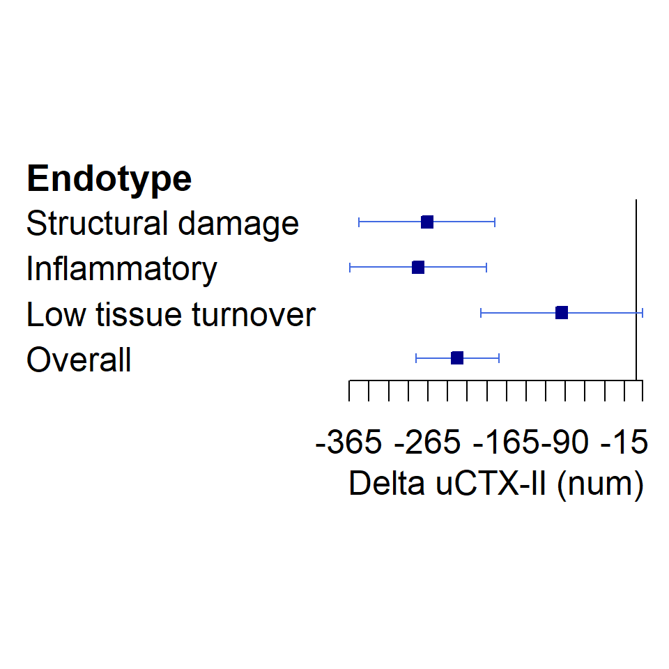

```r
dat.forest = tibble(mean = c(str.estimate.8, infl.estimate.8, low.estimate.8, overall.estimate.8),
       lower = c(str.lower.8, infl.lower.8, low.lower.8, overall.lower.8),
       upper = c(str.upper.8, infl.upper.8, low.upper.8, overall.upper.8),
       endotype = c("Structural damage", "Inflammatory", "Low tissue turnover", "Overall"))

dat.forest %>%
  forestplot(labeltext = endotype,
             xlab = "Delta uCTX-II (num)",
             ci.vertices = TRUE,
             boxsize = 0.25,
             lineheight =  unit(8.6,"mm"),
             col = fpColors(zero = "black")) |>
  fp_add_header(endotype = "Endotype") |>
  fp_set_style(box = "darkblue",
               line = "royalblue",
               txt_gp = fpTxtGp(xlab = gpar(cex = 1.5),
                                ticks = gpar(cex = 1.5),
                                cex = 1.5))
```

# Collect results

```
##             endotype            parameter         effect_size_95_CI
## 1       inflammatory    delta_NRSKNEEPAIN     -0.060 (-9.723,9.604)
## 2       low turnover    delta_NRSKNEEPAIN    -4.622 (-16.122,6.877)
## 3            overall    delta_NRSKNEEPAIN     -3.274 (-9.025,2.478)
## 4  structural damage    delta_NRSKNEEPAIN    -4.920 (-14.515,4.676)
## 5       inflammatory  delta_WOMACFUNC_pct       -2.34 (-12.10,7.42)
## 6       low turnover  delta_WOMACFUNC_pct       -8.65 (-20.11,2.80)
## 7            overall  delta_WOMACFUNC_pct        -4.15 (-9.98,1.68)
## 8  structural damage  delta_WOMACFUNC_pct      -3.51 (-13.16,6.144)
## 9       inflammatory  delta_WOMACPAIN_pct       -1.86 (-11.22,7.50)
## 10      low turnover  delta_WOMACPAIN_pct       -8.75 (-19.76,2.25)
## 11           overall  delta_WOMACPAIN_pct        -4.38 (-9.96,1.21)
## 12 structural damage  delta_WOMACPAIN_pct       -4.43 (-13.70,4.85)
## 13      inflammatory delta_WOMACSTIFF_pct       -3.92 (-14.47,6.64)
## 14      low turnover delta_WOMACSTIFF_pct      -10.73 (-23.12,1.67)
```

[output cut: 18 more lines]

Mean change in parameters split by treatment and endotype.

```r
data %>%
  group_by(predicted_endotype, TREATMENT_SHORT) %>%
  summarize(mean_NRSKNEEPAIN_CH = mean(NRSKNEEPAIN_CH, na.rm = TRUE) %>% round(digits = 3) %>% format(nsmall = 3),
            mean_WOMACPAIN_CH = mean(WOMACPAIN_CH, na.rm = TRUE) %>% round(digits = 2) %>% format(nsmall = 2),
            mean_WOMACFUNC_CH = mean(WOMACFUNC_CH, na.rm = TRUE) %>% round(digits = 2) %>% format(nsmall = 2),
            mean_WOMACSTIFF_CH = mean(WOMACSTIFF_CH, na.rm = TRUE) %>% round(digits = 2) %>% format(nsmall = 2),
            mean_SCTXI_CH = mean(SCTX_CH, na.rm = TRUE) %>% round(digits = 2) %>% format(nsmall = 2),
            mean_UCTXII_CH = mean(UCTXII_CH, na.rm = TRUE) %>% round(digits = 2) %>% format(nsmall = 2),
            mean_SCTXI_CH_NUM = mean(SCTX_CH_NUM, na.rm = TRUE) %>% round(digits = 2) %>% format(nsmall = 2),
            mean_UCTXII_CH_NUM = mean(UCTXII_CH_NUM, na.rm = TRUE) %>% round(digits = 2) %>% format(nsmall = 2)) %>%
  pivot_longer(contains("mean"),
               names_to = "parameter",
               values_to = "mean_change") %>%
  arrange(parameter, predicted_endotype) %>%
  as.data.frame
```

```
##    predicted_endotype TREATMENT_SHORT           parameter mean_change
## 1   structural_damage         PLACEBO mean_NRSKNEEPAIN_CH     -10.000
## 2   structural_damage         MIV-711 mean_NRSKNEEPAIN_CH     -15.517
## 3        inflammatory         PLACEBO mean_NRSKNEEPAIN_CH     -13.929
## 4        inflammatory         MIV-711 mean_NRSKNEEPAIN_CH     -14.634
## 5        low_turnover         PLACEBO mean_NRSKNEEPAIN_CH     -15.882
## 6        low_turnover         MIV-711 mean_NRSKNEEPAIN_CH     -18.936
## 7   structural_damage         PLACEBO       mean_SCTXI_CH       -9.92
## 8   structural_damage         MIV-711       mean_SCTXI_CH      -41.91
## 9        inflammatory         PLACEBO       mean_SCTXI_CH       18.99
## 10       inflammatory         MIV-711       mean_SCTXI_CH      -39.43
## 11       low_turnover         PLACEBO       mean_SCTXI_CH        9.76
## 12       low_turnover         MIV-711       mean_SCTXI_CH      -28.07
## 13  structural_damage         PLACEBO   mean_SCTXI_CH_NUM       -0.09
## 14  structural_damage         MIV-711   mean_SCTXI_CH_NUM       -0.28
```

[output cut: 34 more lines]

Mean change in parameters split by treatment on overall population.

```r
data %>%
  group_by(TREATMENT_SHORT) %>%
  summarize(mean_NRSKNEEPAIN_CH = mean(NRSKNEEPAIN_CH, na.rm = TRUE) %>% round(digits = 3) %>% format(nsmall = 3),
            mean_WOMACPAIN_CH = mean(WOMACPAIN_CH, na.rm = TRUE) %>% round(digits = 2) %>% format(nsmall = 2),
            mean_WOMACFUNC_CH = mean(WOMACFUNC_CH, na.rm = TRUE) %>% round(digits = 2) %>% format(nsmall = 2),
            mean_WOMACSTIFF_CH = mean(WOMACSTIFF_CH, na.rm = TRUE) %>% round(digits = 2) %>% format(nsmall = 2),
            mean_SCTXI_CH = mean(SCTX_CH, na.rm = TRUE) %>% round(digits = 2) %>% format(nsmall = 2),
            mean_UCTXII_CH = mean(UCTXII_CH, na.rm = TRUE) %>% round(digits = 2) %>% format(nsmall = 2),
            mean_SCTXI_CH_NUM = mean(SCTX_CH_NUM, na.rm = TRUE) %>% round(digits = 2) %>% format(nsmall = 2),
            mean_UCTXII_CH_NUM = mean(UCTXII_CH_NUM, na.rm = TRUE) %>% round(digits = 2) %>% format(nsmall = 2)) %>%
  pivot_longer(contains("mean"),
               names_to = "parameter",
               values_to = "mean_change") %>%
  arrange(parameter) %>%
  as.data.frame
```

```
##    TREATMENT_SHORT           parameter mean_change
## 1          PLACEBO mean_NRSKNEEPAIN_CH     -13.043
## 2          MIV-711 mean_NRSKNEEPAIN_CH     -16.370
## 3          PLACEBO       mean_SCTXI_CH        6.66
## 4          MIV-711       mean_SCTXI_CH      -36.76
## 5          PLACEBO   mean_SCTXI_CH_NUM        0.00
## 6          MIV-711   mean_SCTXI_CH_NUM       -0.19
## 7          PLACEBO      mean_UCTXII_CH       11.47
## 8          MIV-711      mean_UCTXII_CH      -39.20
## 9          PLACEBO  mean_UCTXII_CH_NUM       16.93
## 10         MIV-711  mean_UCTXII_CH_NUM     -195.85
## 11         PLACEBO   mean_WOMACFUNC_CH       -9.90
## 12         MIV-711   mean_WOMACFUNC_CH      -15.19
## 13         PLACEBO   mean_WOMACPAIN_CH       -9.80
## 14         MIV-711   mean_WOMACPAIN_CH      -14.79
## 15         PLACEBO  mean_WOMACSTIFF_CH       -9.78
## 16         MIV-711  mean_WOMACSTIFF_CH      -15.75
```